# Decision Trees

Valentina Zangirolami (valentina.zangirolami@unimib.it)

2025-05-09

```r
#load libraries
library(car)
library(ggplot2)
library(tidymodels)
library(tidyverse)
library(rpart.plot)
library(vip)
```

## *Dataset: ESG DATA*

```r
esg_data <- read.csv("esg_financial_dataset.csv")
head(esg_data)
```

```
##   Industry        Region Revenue ProfitMargin MarketCap GrowthRate ESG_Overall
## 1   Retail Latin America   593.2          4.2     248.4       -1.8        57.7
## 2   Retail Latin America   636.7          5.3     373.9        7.3        57.8
## 3   Retail Latin America   687.0          4.6     460.1        7.9        58.5
## 4   Retail Latin America   734.5          5.0     628.8        6.9        59.2
## 5   Retail          Asia  3106.4          0.8     514.3       -1.9        64.0
## 6   Retail          Asia  3691.6         -0.7    2523.2       18.8        66.0
##   ESG_Environmental ESG_Social ESG_Governance CarbonEmissions WaterUsage
## 1              69.0       27.1           76.9         42536.3    21268.2
## 2              68.3       27.0           78.1         45956.3    22978.2
## 3              68.9       29.9           76.8         49289.1    24644.5
## 4              70.7       29.1           78.0         51805.8    25902.9
## 5              66.7       57.7           67.8        227761.4   113880.7
## 6              66.6       61.6           70.0        271015.1   135507.6
##   EnergyConsumption
## 1           85072.6
## 2           91912.6
## 3           98578.1
## 4          103611.7
## 5          455522.7
## 6          542030.3
```

See the description and data analysis in Multiple Linear regression file.

From this class, we introduce tidymodels! You can use it also to fit lm, glm, gam and mars. Have a look [here](https://www.tidymodels.org/start/models/)

Before starting, we need to use holdout sample or cross-validation to evaluate our models. In this case, we use cross-validation

```r
set.seed(123)  # For reproducibility
split <- initial_split(esg_data, prop = 0.8)

train_data <- training(split)
val_data <- testing(split)

folds <- vfold_cv(train_data, v = 5)
folds
```

```
## #  5-fold cross-validation
## # A tibble: 5 × 2
##   splits             id
##   <list>             <chr>
## 1 <split [2560/640]> Fold1
## 2 <split [2560/640]> Fold2
## 3 <split [2560/640]> Fold3
## 4 <split [2560/640]> Fold4
## 5 <split [2560/640]> Fold5
```

Tidymodels involves 4 steps:

**1. Build a model**

With tidymodels, we need to define the functional form of our model. Thus, in this case, we need to call decision_tree specifyng the main hyperparameters (you can look them up on the help page) and, if you want, you can also call the engine (i.e. what kind of decision tree implementation you want). The most popular library on R is rpart. After that, we should also specify if we are considering *regression* or *classification*.

```r
tree_spec <- decision_tree(cost_complexity = 0.01, tree_depth=30, min_n=20) |>
  set_engine("rpart") |> set_mode("regression")
```

We set the default values for hyperparameters:

- **cost_complexity** controls the pruning where high values lead to highly prune the tree
- **tree_depth** controls the depth of the trees: high values increases complexity
- **min_n** is the minimum number of obs for each leaf

**2. Create the recipe**

Another component of tidymodels is the recipe. In general, we can use it to preprocess the data and also create new predictors. In our case, we already add new features but the recipe can be helpful to perform most classical operation of data preprocessing or feature engineering. For instance, in this case we will perform one-hot encoding for categorical predictors and we will remove columns from the data when the training set data have a single value (hence, it is better add it after step_dummy)

```r
esg_recipe <- recipe(MarketCap~., train_data) %>%
  step_dummy(all_nominal_predictors()) %>%
  step_zv(all_predictors())
```

**3. Define a workflow**

The third step requires to create a workflow: it is used to merge the model and the recipe

```r
rt_work <-
  workflow() |>
  add_model(tree_spec) |>
  add_recipe(esg_recipe)
```

**4. Fit the model**

Finally, we can fit our model

```r
trees_cv_results <- fit_resamples(rt_work, folds)
trees_fit_1 <- fit(rt_work, train_data)

# Get predictions on training data
train_preds <- predict(trees_fit_1, new_data = train_data) %>%
  bind_cols(train_data)  # Attach true values
# Get predictions on validation data
val_preds <- predict(trees_fit_1, new_data = val_data) %>%
  bind_cols(val_data)  # Attach true values

# Compute metrics (e.g., RMSE, R-squared for regression)
metrics <- metric_set(rmse, rsq)
train_metrics <- metrics(train_preds, truth = MarketCap, estimate = .pred)
val_metrics <- metrics(val_preds, truth = MarketCap, estimate = .pred)

round(train_metrics$.estimate, 4)
```

```
## [1] 20232.6439     0.8579
```

```r
round(val_metrics$.estimate,4)
```

```
## [1] 23907.6382     0.7485
```

The results highlight a slight problem of overfitting, then it’s better avoiding to increase the complexity of the tree. We can try to increase cost complexity

New hyperparameters:

```r
tree_spec <- decision_tree(cost_complexity = 0.1, tree_depth=30, min_n=20) |>
  set_engine("rpart") |> set_mode("regression")

rt_work <-
  workflow() |>
  add_model(tree_spec) |>
  add_recipe(esg_recipe)

trees_fit_1 <- fit(rt_work, train_data)

# Get predictions on training data
train_preds <- predict(trees_fit_1, new_data = train_data) %>%
  bind_cols(train_data)  # Attach true values
# Get predictions on validation data
val_preds <- predict(trees_fit_1, new_data = val_data) %>%
  bind_cols(val_data)  # Attach true values

# Compute metrics (e.g., RMSE, R-squared for regression)
metrics <- metric_set(rmse, rsq)
train_metrics <- metrics(train_preds, truth = MarketCap, estimate = .pred)
val_metrics <- metrics(val_preds, truth = MarketCap, estimate = .pred)

round(train_metrics$.estimate, 4)
```

```
## [1] 35303.8588     0.5674
```

```r
round(val_metrics$.estimate,4)
```

```
## [1] 35392.9072     0.4265
```

We obtained worst results, and we prefer the first model.

Even if it is expensive, we can use grid search with cross-validation to select best hyperparameters

```r
tree_spec <- decision_tree(cost_complexity = 0.01, tree_depth=tune(), min_n=tune()) |>
  set_engine("rpart") |> set_mode("regression")

tree_grid <- grid_regular(
  tree_depth(),
  min_n(),
  levels = 20  # Number of values for each parameter
)

rt_work <-
  workflow() |>
  add_model(tree_spec) |>
  add_recipe(esg_recipe)


tree_res <- tune_grid(
  rt_work,
  resamples = folds,
  grid = tree_grid,
  metrics = metric_set(rmse, rsq)  # Choose appropriate metrics
)

best_tree <- select_best(tree_res,metric = "rmse")

final_wf <- finalize_workflow(rt_work, best_tree)

final_fit <- fit(final_wf, train_data)

# Get predictions on training data
train_preds <- predict(final_fit, new_data = train_data) %>%
  bind_cols(train_data)  # Attach true values
# Get predictions on validation data
val_preds <- predict(final_fit, new_data = val_data) %>%
  bind_cols(val_data)  # Attach true values

# Compute metrics (e.g., RMSE, R-squared for regression)
metrics <- metric_set(rmse, rsq)
train_metrics <- metrics(train_preds, truth = MarketCap, estimate = .pred)
val_metrics <- metrics(val_preds, truth = MarketCap, estimate = .pred)

round(train_metrics$.estimate, 4)
```

```
## [1] 19376.4581     0.8697
```

```r
round(val_metrics$.estimate,4)
```

```
## [1] 20010.2248     0.8343
```

We obtained the best results in validation set where overfitting is not a strong concern.

The best hyperparameters are

```r
best_tree
```

```
## # A tibble: 1 × 3
##   tree_depth min_n .config
##        <int> <int> <chr>
## 1          5     8 Preprocessor1_Model050
```

We can make the plot of this last model.

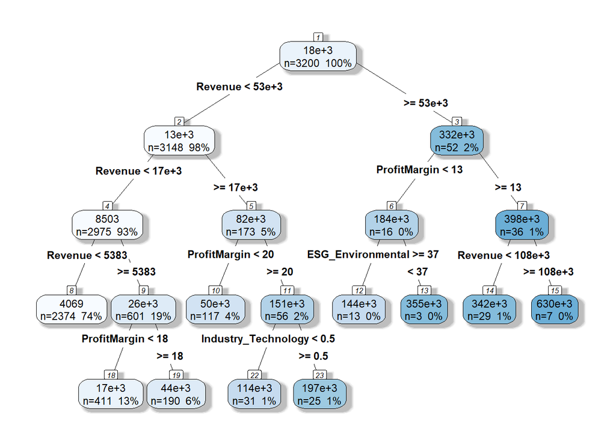

```r
final_model <- extract_fit_engine(final_fit)

rpart.plot(
 final_model,
  type = 4,
  extra = 101,
  box.palette = "Blues",
  nn = TRUE,
  fallen.leaves = FALSE,
  shadow.col = "gray"
)
```

In the first line, we can observe that the first splitting variable was *Revenue* with the splitting value *53e+3*. We obtain two nodes that are split with two different splitting variables: on the left, *Revenue* is chosen again and, on the right, *ProfitMargin*. At the end of each path, we can obtain the estimated value of the response for each partition of the feature space.

**Feature importance**

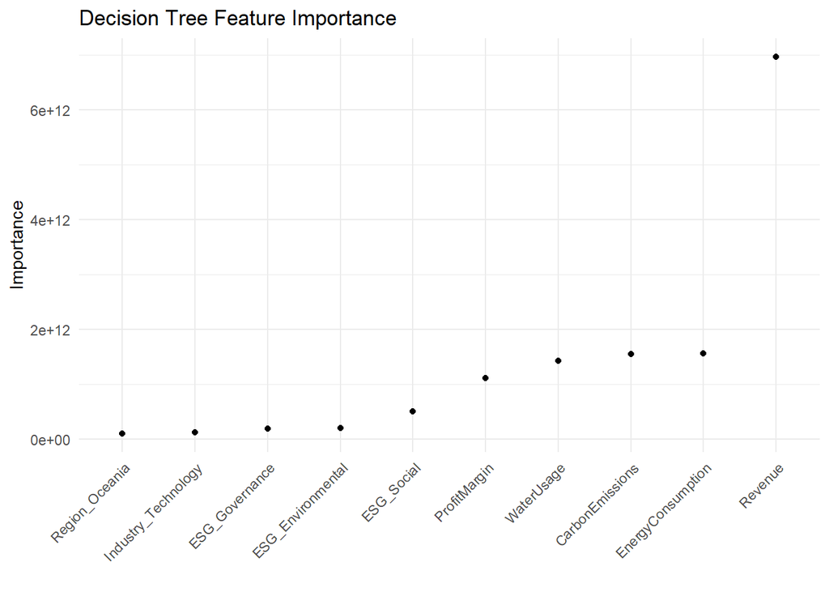

```r
vip(final_model, geom = "point", horizontal = FALSE) +
  ggtitle("Decision Tree Feature Importance") +
  theme_minimal() +
  theme(axis.text.x = element_text(angle = 45, hjust = 1, vjust = 1))
```